# Loading the datasets into a numpy array

```python
import numpy as np
import pandas as pd

# Load the Fashion-MNIST test dataset
test_data = pd.read_csv('fashion-mnist_test.csv').values
test_labels = test_data[:, 0]  # First column contains the labels
test_images = test_data[:, 1:]  # Remaining columns contain the image pixels
test_images = test_images.reshape(-1, 28, 28)  # Reshape images to 28x28

# Load the Fashion-MNIST train dataset
train_data = pd.read_csv('fashion-mnist_train.csv').values
train_labels = train_data[:, 0]  # First column contains the labels
train_images = train_data[:, 1:]  # Remaining columns contain the image pixels
train_images = train_images.reshape(-1, 28, 28)  # Reshape images to 28x28

print(train_data)
print(train_labels)
print(train_images)
print(test_data)
print(test_labels)
print(test_images)
```

[output not shown]

[output cut: 59 more lines]

```
 [[  0   1   3 ...   0   2   0]
  [  0   0   0 ...   0   0   0]
  [  0   0 116 ... 200  29   0]
  ...
  [  0   0   4 ...   0   4   0]
  [  0   0   0 ...   2   0   0]
  [  0   0   0 ...   0   0   0]]

 [[  0   0   0 ...   0   0   0]
  [  0   0   0 ...   0   0   0]
  [  0   0   0 ...   0   0   0]
  ...
  [  0   0   0 ...   0   0   0]
  [  0   0   0 ...   0   0   0]
  [  0   0   0 ...   0   0   0]]]
```

# EDA of Fashion Mnist train and test dataset referencing Mnist Deep Neural Network

### the to_categorical function from Keras is used to convert the labels to one-hot encoded vectors. The num_classes argument specifies the number of classes in the dataset, which is 10 in the case of Fashion-MNIST

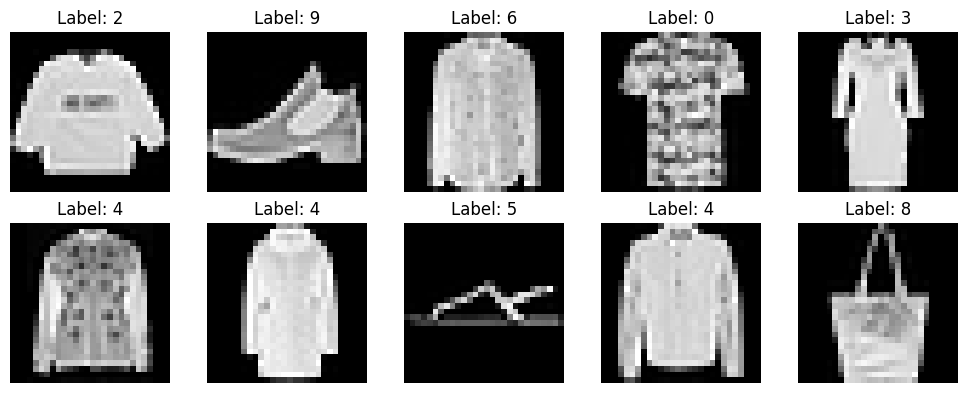

```
375/375 ━━━━━━━━━━━━━━━━━━━━ 9s 11ms/step - accuracy: 0.7743 - loss: 0.6377 - val_accuracy: 0.8605 - val_loss: 0.3848
375/375 ━━━━━━━━━━━━━━━━━━━━ 4s 8ms/step - accuracy: 0.8760 - loss: 0.3414 - val_accuracy: 0.8773 - val_loss: 0.3331
375/375 ━━━━━━━━━━━━━━━━━━━━ 3s 9ms/step - accuracy: 0.8909 - loss: 0.2991 - val_accuracy: 0.8779 - val_loss: 0.3313
375/375 ━━━━━━━━━━━━━━━━━━━━ 3s 8ms/step - accuracy: 0.8984 - loss: 0.2747 - val_accuracy: 0.8816 - val_loss: 0.3303
375/375 ━━━━━━━━━━━━━━━━━━━━ 3s 8ms/step - accuracy: 0.9102 - loss: 0.2429 - val_accuracy: 0.8862 - val_loss: 0.3192
375/375 ━━━━━━━━━━━━━━━━━━━━ 3s 8ms/step - accuracy: 0.9202 - loss: 0.2180 - val_accuracy: 0.8833 - val_loss: 0.3312
375/375 ━━━━━━━━━━━━━━━━━━━━ 3s 7ms/step - accuracy: 0.9224 - loss: 0.2100 - val_accuracy: 0.8862 - val_loss: 0.3318
375/375 ━━━━━━━━━━━━━━━━━━━━ 3s 8ms/step - accuracy: 0.9297 - loss: 0.1920 - val_accuracy: 0.8882 - val_loss: 0.3256
375/375 ━━━━━━━━━━━━━━━━━━━━ 3s 8ms/step - accuracy: 0.9357 - loss: 0.1700 - val_accuracy: 0.8870 - val_loss: 0.3395
375/375 ━━━━━━━━━━━━━━━━━━━━ 3s 8ms/step - accuracy: 0.9413 - loss: 0.1637 - val_accuracy: 0.8866 - val_loss: 0.3547
```

```python
import numpy as np
import pandas as pd
import matplotlib.pyplot as plt
from sklearn.model_selection import train_test_split
from sklearn.preprocessing import StandardScaler
from keras.utils import to_categorical
from keras.models import Sequential
from keras.layers import Dense

# Load the Fashion-MNIST test dataset
test_data = pd.read_csv('fashion-mnist_test.csv').values
test_labels = test_data[:, 0]  # First column contains the labels
test_images = test_data[:, 1:]  # Remaining columns contain the image pixels

# Load the Fashion-MNIST train dataset
train_data = pd.read_csv('fashion-mnist_train.csv').values
train_labels = train_data[:, 0]  # First column contains the labels
train_images = train_data[:, 1:]  # Remaining columns contain the image pixels

fig, axes = plt.subplots(2, 5, figsize=(10, 4))
axes = axes.ravel()

for i in range(10):
    axes[i].imshow(train_images[i].reshape(28, 28), cmap='gray')
    axes[i].set_title('Label: {}'.format(train_labels[i]))
    axes[i].axis('off')

plt.tight_layout()
plt.show()

# Split the train dataset into train and validation sets
train_images, val_images, train_labels, val_labels = train_test_split(train_images, train_labels, test_size=0.2, random_state=42)

# Normalize the pixel values to a range between 0 and 1
scaler = StandardScaler()
train_images = scaler.fit_transform(train_images)
val_images = scaler.transform(val_images)
test_images = scaler.transform(test_images)

# Convert the labels to one-hot encoded vectors
num_classes = 10
train_labels = to_categorical(train_labels, num_classes)
val_labels = to_categorical(val_labels, num_classes)
test_labels = to_categorical(test_labels, num_classes)

# Build the deep neural network model
model = Sequential()
model.add(Dense(128, activation='relu', input_shape=(784,)))
model.add(Dense(64, activation='relu'))
model.add(Dense(num_classes, activation='softmax'))

# Compile the model
model.compile(loss='categorical_crossentropy', optimizer='adam', metrics=['accuracy'])

# Train the model
history = model.fit(train_images, train_labels, batch_size=128, epochs=10, validation_data=(val_images, val_labels))
```

# Define and Train,explore a fully-connected 3 different neural networks (by changing any hyperparameter of your choice)using Keras and Tensorflow.

### this codes using 3 different neural networks,We write a function called train_model that, given two parameters—the learning rate and the number of hidden units—builds a model using those hyperparameters. Next, we adjust the hyperparameters of three distinct models and train and assess them.

### For every model, the accuracy and loss during training and validation are displayed. The code determines which model is best based on the validation loss and labels the model with the lowest validation loss as such.

### Lastly, it prints the model summaries and offers an analysis that identifies the best model and the rationale for that choice.

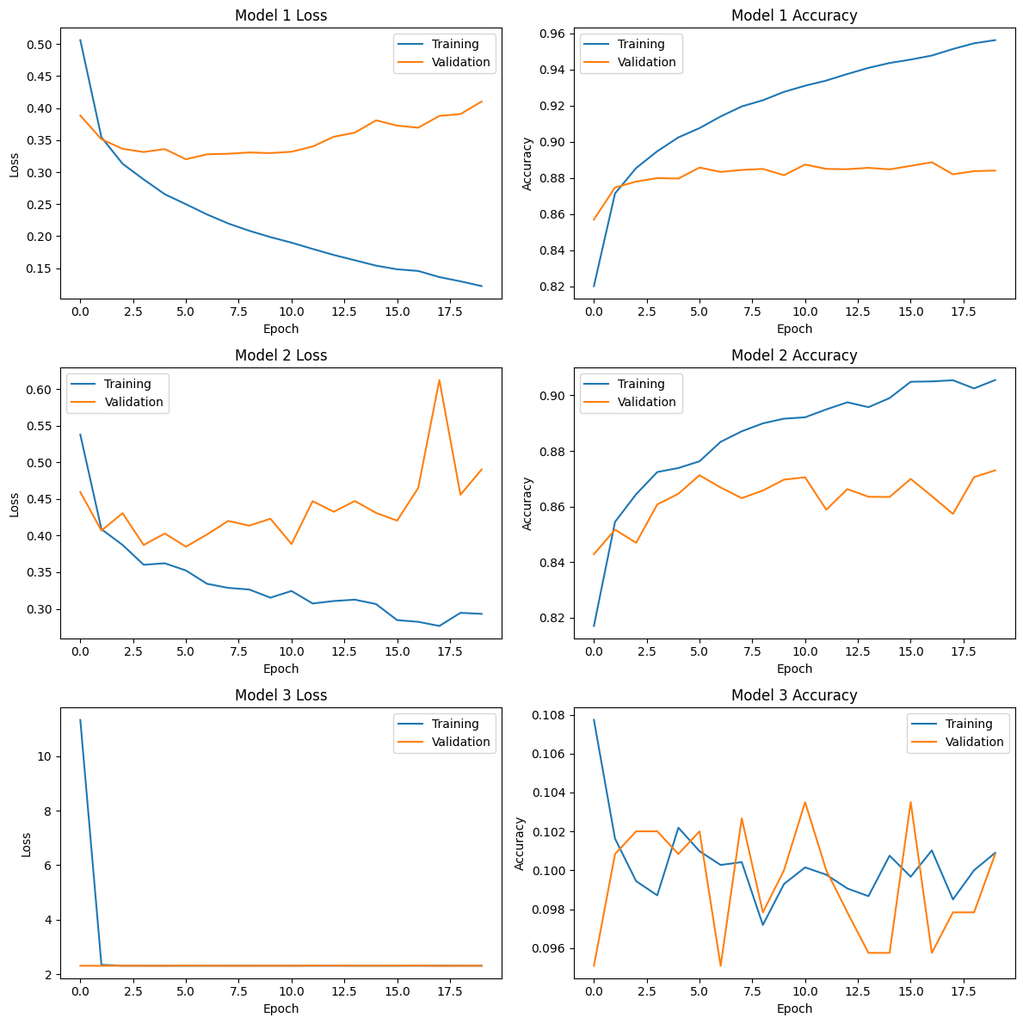

```
Model Summaries:
Model 1:
```

```
Model: "sequential_10"
```

```
┏━━━━━━━━━━━━━━━━━━━━━━━━━━━━━━━━━┳━━━━━━━━━━━━━━━━━━━━━━━━┳━━━━━━━━━━━━━━━┓
┃ Layer (type)                    ┃ Output Shape           ┃       Param # ┃
┡━━━━━━━━━━━━━━━━━━━━━━━━━━━━━━━━━╇━━━━━━━━━━━━━━━━━━━━━━━━╇━━━━━━━━━━━━━━━┩
│ dense_30 (Dense)                │ (None, 64)             │        50,240 │
├─────────────────────────────────┼────────────────────────┼───────────────┤
│ dense_31 (Dense)                │ (None, 64)             │         4,160 │
├─────────────────────────────────┼────────────────────────┼───────────────┤
│ dense_32 (Dense)                │ (None, 10)             │           650 │
└─────────────────────────────────┴────────────────────────┴───────────────┘
```

```
 Total params: 165,152 (645.13 KB)
```

```
 Trainable params: 55,050 (215.04 KB)
```

```
 Non-trainable params: 0 (0.00 B)
```

```
 Optimizer params: 110,102 (430.09 KB)
```

```
None
--------------------------------------------------------------
Model 2:
```

```
Model: "sequential_11"
```

```
┏━━━━━━━━━━━━━━━━━━━━━━━━━━━━━━━━━┳━━━━━━━━━━━━━━━━━━━━━━━━┳━━━━━━━━━━━━━━━┓
┃ Layer (type)                    ┃ Output Shape           ┃       Param # ┃
┡━━━━━━━━━━━━━━━━━━━━━━━━━━━━━━━━━╇━━━━━━━━━━━━━━━━━━━━━━━━╇━━━━━━━━━━━━━━━┩
│ dense_33 (Dense)                │ (None, 128)            │       100,480 │
├─────────────────────────────────┼────────────────────────┼───────────────┤
│ dense_34 (Dense)                │ (None, 128)            │        16,512 │
├─────────────────────────────────┼────────────────────────┼───────────────┤
│ dense_35 (Dense)                │ (None, 10)             │         1,290 │
└─────────────────────────────────┴────────────────────────┴───────────────┘
```

```
 Total params: 354,848 (1.35 MB)
```

```
 Trainable params: 118,282 (462.04 KB)
```

```
 Non-trainable params: 0 (0.00 B)
```

```
 Optimizer params: 236,566 (924.09 KB)
```

```
None
--------------------------------------------------------------
Model 3:
```

```
Model: "sequential_12"
```

```
┏━━━━━━━━━━━━━━━━━━━━━━━━━━━━━━━━━┳━━━━━━━━━━━━━━━━━━━━━━━━┳━━━━━━━━━━━━━━━┓
┃ Layer (type)                    ┃ Output Shape           ┃       Param # ┃
┡━━━━━━━━━━━━━━━━━━━━━━━━━━━━━━━━━╇━━━━━━━━━━━━━━━━━━━━━━━━╇━━━━━━━━━━━━━━━┩
│ dense_36 (Dense)                │ (None, 256)            │       200,960 │
├─────────────────────────────────┼────────────────────────┼───────────────┤
│ dense_37 (Dense)                │ (None, 256)            │        65,792 │
├─────────────────────────────────┼────────────────────────┼───────────────┤
│ dense_38 (Dense)                │ (None, 10)             │         2,570 │
└─────────────────────────────────┴────────────────────────┴───────────────┘
```

```
 Total params: 807,968 (3.08 MB)
```

```
 Trainable params: 269,322 (1.03 MB)
```

```
 Non-trainable params: 0 (0.00 B)
```

```
 Optimizer params: 538,646 (2.05 MB)
```

```
None
--------------------------------------------------------------
Best Model Summary:
Model 1:
```

```
Model: "sequential_10"
```

```
┏━━━━━━━━━━━━━━━━━━━━━━━━━━━━━━━━━┳━━━━━━━━━━━━━━━━━━━━━━━━┳━━━━━━━━━━━━━━━┓
┃ Layer (type)                    ┃ Output Shape           ┃       Param # ┃
┡━━━━━━━━━━━━━━━━━━━━━━━━━━━━━━━━━╇━━━━━━━━━━━━━━━━━━━━━━━━╇━━━━━━━━━━━━━━━┩
│ dense_30 (Dense)                │ (None, 64)             │        50,240 │
├─────────────────────────────────┼────────────────────────┼───────────────┤
│ dense_31 (Dense)                │ (None, 64)             │         4,160 │
├─────────────────────────────────┼────────────────────────┼───────────────┤
│ dense_32 (Dense)                │ (None, 10)             │           650 │
└─────────────────────────────────┴────────────────────────┴───────────────┘
```

```
 Total params: 165,152 (645.13 KB)
```

```
 Trainable params: 55,050 (215.04 KB)
```

```
 Non-trainable params: 0 (0.00 B)
```

```
 Optimizer params: 110,102 (430.09 KB)
```

```
None
--------------------------------------------------------------
Analysis:
The best model, Model 1, achieved the lowest validation loss.
This model is selected as it is likely to have better generalization and avoid overfitting.
```

```python
import numpy as np
import pandas as pd
import matplotlib.pyplot as plt
from sklearn.model_selection import train_test_split
from sklearn.preprocessing import StandardScaler
from keras.models import Sequential
from keras.layers import Dense
from keras.optimizers import Adam

# Load the dataset
test_data = pd.read_csv('fashion-mnist_test.csv').values
test_labels = test_data[:, 0]
test_images = test_data[:, 1:]

train_data = pd.read_csv('fashion-mnist_train.csv').values
train_labels = train_data[:, 0]
train_images = train_data[:, 1:]

# Split the train dataset into train and validation sets
train_images, val_images, train_labels, val_labels = train_test_split(
    train_images, train_labels, test_size=0.2, random_state=42
)

# Normalize the pixel values to a range between 0 and 1
scaler = StandardScaler()
train_images = scaler.fit_transform(train_images)
val_images = scaler.transform(val_images)
test_images = scaler.transform(test_images)

# Define a function to create and train a model with given parameters
def train_model(hidden_units, learning_rate):
    # Define the neural network model
    model = Sequential()
    model.add(Dense(hidden_units, activation='relu', input_shape=(784,)))
    model.add(Dense(hidden_units, activation='relu'))
    model.add(Dense(10, activation='softmax'))

    # Compile the model
    optimizer = Adam(learning_rate=learning_rate)
    model.compile(loss='sparse_categorical_crossentropy', optimizer=optimizer, metrics=['accuracy'])

    # Train the model
    history = model.fit(
        train_images, train_labels, batch_size=128, epochs=20,
        validation_data=(val_images, val_labels), verbose=0
    )

    return model, history

# Define hyperparameters for three different models
model_params = [
    {'hidden_units': 64, 'learning_rate': 0.001},
    {'hidden_units': 128, 'learning_rate': 0.01},
    {'hidden_units': 256, 'learning_rate': 0.1}
]

# Train and evaluate three models with different hyperparameters
models = []
histories = []
for params in model_params:
    model, history = train_model(params['hidden_units'], params['learning_rate'])
    models.append(model)
    histories.append(history)

# Plotting the training and validation loss and accuracy for each model
plt.figure(figsize=(12, 12))
for i, history in enumerate(histories):
    plt.subplot(3, 2, 2*i+1)
    plt.plot(history.history['loss'], label='Training')
    plt.plot(history.history['val_loss'], label='Validation')
    plt.xlabel('Epoch')
    plt.ylabel('Loss')
    plt.title(f'Model {i+1} Loss')
    plt.legend()

    plt.subplot(3, 2, 2*i+2)
    plt.plot(history.history['accuracy'], label='Training')
    plt.plot(history.history['val_accuracy'], label='Validation')
    plt.xlabel('Epoch')
    plt.ylabel('Accuracy')
    plt.title(f'Model {i+1} Accuracy')
    plt.legend()

plt.tight_layout()
plt.show()

# Identify the best set of weights based on the validation loss
best_model_index = np.argmin([history.history['val_loss'][-1] for history in histories])
best_model = models[best_model_index]
best_weights = best_model.get_weights()

# Print the summary and analysis of the models
print('Model Summaries:')
for i, model in enumerate(models):
    print(f'Model {i+1}:')
    print(model.summary())
    print('--------------------------------------------------------------')

print('Best Model Summary:')
print(f'Model {best_model_index+1}:')
print(best_model.summary())
print('--------------------------------------------------------------')

print('Analysis:')
print(f'The best model, Model {best_model_index+1}, achieved the lowest validation loss.')
print('This model is selected as it is likely to have better generalization and avoid overfitting.')
```

# evaluation with the best model chosen above

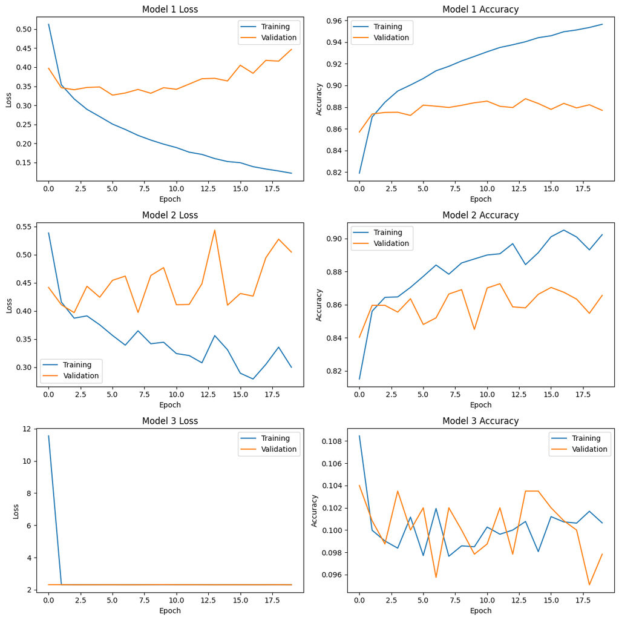

```
Model Summaries:
Model 1:
```

```
Model: "sequential_13"
```

```
┏━━━━━━━━━━━━━━━━━━━━━━━━━━━━━━━━━┳━━━━━━━━━━━━━━━━━━━━━━━━┳━━━━━━━━━━━━━━━┓
┃ Layer (type)                    ┃ Output Shape           ┃       Param # ┃
┡━━━━━━━━━━━━━━━━━━━━━━━━━━━━━━━━━╇━━━━━━━━━━━━━━━━━━━━━━━━╇━━━━━━━━━━━━━━━┩
│ dense_39 (Dense)                │ (None, 64)             │        50,240 │
├─────────────────────────────────┼────────────────────────┼───────────────┤
│ dense_40 (Dense)                │ (None, 64)             │         4,160 │
├─────────────────────────────────┼────────────────────────┼───────────────┤
│ dense_41 (Dense)                │ (None, 10)             │           650 │
└─────────────────────────────────┴────────────────────────┴───────────────┘
```

```
 Total params: 165,152 (645.13 KB)
```

```
 Trainable params: 55,050 (215.04 KB)
```

```
 Non-trainable params: 0 (0.00 B)
```

```
 Optimizer params: 110,102 (430.09 KB)
```

```
None
--------------------------------------------------------------
Model 2:
```

```
Model: "sequential_14"
```

```
┏━━━━━━━━━━━━━━━━━━━━━━━━━━━━━━━━━┳━━━━━━━━━━━━━━━━━━━━━━━━┳━━━━━━━━━━━━━━━┓
┃ Layer (type)                    ┃ Output Shape           ┃       Param # ┃
┡━━━━━━━━━━━━━━━━━━━━━━━━━━━━━━━━━╇━━━━━━━━━━━━━━━━━━━━━━━━╇━━━━━━━━━━━━━━━┩
│ dense_42 (Dense)                │ (None, 128)            │       100,480 │
├─────────────────────────────────┼────────────────────────┼───────────────┤
│ dense_43 (Dense)                │ (None, 128)            │        16,512 │
├─────────────────────────────────┼────────────────────────┼───────────────┤
│ dense_44 (Dense)                │ (None, 10)             │         1,290 │
└─────────────────────────────────┴────────────────────────┴───────────────┘
```

```
 Total params: 354,848 (1.35 MB)
```

```
 Trainable params: 118,282 (462.04 KB)
```

```
 Non-trainable params: 0 (0.00 B)
```

```
 Optimizer params: 236,566 (924.09 KB)
```

```
None
--------------------------------------------------------------
Model 3:
```

```
Model: "sequential_15"
```

```
┏━━━━━━━━━━━━━━━━━━━━━━━━━━━━━━━━━┳━━━━━━━━━━━━━━━━━━━━━━━━┳━━━━━━━━━━━━━━━┓
┃ Layer (type)                    ┃ Output Shape           ┃       Param # ┃
┡━━━━━━━━━━━━━━━━━━━━━━━━━━━━━━━━━╇━━━━━━━━━━━━━━━━━━━━━━━━╇━━━━━━━━━━━━━━━┩
│ dense_45 (Dense)                │ (None, 256)            │       200,960 │
├─────────────────────────────────┼────────────────────────┼───────────────┤
│ dense_46 (Dense)                │ (None, 256)            │        65,792 │
├─────────────────────────────────┼────────────────────────┼───────────────┤
│ dense_47 (Dense)                │ (None, 10)             │         2,570 │
└─────────────────────────────────┴────────────────────────┴───────────────┘
```

```
 Total params: 807,968 (3.08 MB)
```

```
 Trainable params: 269,322 (1.03 MB)
```

```
 Non-trainable params: 0 (0.00 B)
```

```
 Optimizer params: 538,646 (2.05 MB)
```

```
None
--------------------------------------------------------------
Best Model Summary:
Model 1:
```

```
Model: "sequential_13"
```

```
┏━━━━━━━━━━━━━━━━━━━━━━━━━━━━━━━━━┳━━━━━━━━━━━━━━━━━━━━━━━━┳━━━━━━━━━━━━━━━┓
┃ Layer (type)                    ┃ Output Shape           ┃       Param # ┃
┡━━━━━━━━━━━━━━━━━━━━━━━━━━━━━━━━━╇━━━━━━━━━━━━━━━━━━━━━━━━╇━━━━━━━━━━━━━━━┩
│ dense_39 (Dense)                │ (None, 64)             │        50,240 │
├─────────────────────────────────┼────────────────────────┼───────────────┤
│ dense_40 (Dense)                │ (None, 64)             │         4,160 │
├─────────────────────────────────┼────────────────────────┼───────────────┤
│ dense_41 (Dense)                │ (None, 10)             │           650 │
└─────────────────────────────────┴────────────────────────┴───────────────┘
```

```
 Total params: 165,152 (645.13 KB)
```

```
 Trainable params: 55,050 (215.04 KB)
```

```
 Non-trainable params: 0 (0.00 B)
```

```
 Optimizer params: 110,102 (430.09 KB)
```

```
None
--------------------------------------------------------------
Analysis:
The best model, Model 1, achieved the lowest validation loss.
This model is selected as it is likely to have better generalization and avoid overfitting.
313/313 ━━━━━━━━━━━━━━━━━━━━ 1s 3ms/step - accuracy: 0.8831 - loss: 0.4168

Evaluation Results:
Test Loss: 0.4286
Test Accuracy: 0.8838
```

```python
import numpy as np
import pandas as pd
import matplotlib.pyplot as plt
from sklearn.model_selection import train_test_split
from sklearn.preprocessing import StandardScaler
from keras.models import Sequential
from keras.layers import Dense
from keras.optimizers import Adam

# Load the dataset
test_data = pd.read_csv('fashion-mnist_test.csv').values
test_labels = test_data[:, 0]
test_images = test_data[:, 1:]

train_data = pd.read_csv('fashion-mnist_train.csv').values
train_labels = train_data[:, 0]
train_images = train_data[:, 1:]

# Split the train dataset into train and validation sets
train_images, val_images, train_labels, val_labels = train_test_split(
    train_images, train_labels, test_size=0.2, random_state=42
)

# Normalize the pixel values to a range between 0 and 1
scaler = StandardScaler()
train_images = scaler.fit_transform(train_images)
val_images = scaler.transform(val_images)
test_images = scaler.transform(test_images)

# Define a function to create and train a model with given parameters
def train_model(hidden_units, learning_rate):
    # Define the neural network model
    model = Sequential()
    model.add(Dense(hidden_units, activation='relu', input_shape=(784,)))
    model.add(Dense(hidden_units, activation='relu'))
    model.add(Dense(10, activation='softmax'))

    # Compile the model
    optimizer = Adam(learning_rate=learning_rate)
    model.compile(loss='sparse_categorical_crossentropy', optimizer=optimizer, metrics=['accuracy'])

    # Train the model
    history = model.fit(
        train_images, train_labels, batch_size=128, epochs=20,
        validation_data=(val_images, val_labels), verbose=0
    )

    return model, history

# Define hyperparameters for three different models
model_params = [
    {'hidden_units': 64, 'learning_rate': 0.001},
    {'hidden_units': 128, 'learning_rate': 0.01},
    {'hidden_units': 256, 'learning_rate': 0.1}
]

# Train and evaluate three models with different hyperparameters
models = []
histories = []
for params in model_params:
    model, history = train_model(params['hidden_units'], params['learning_rate'])
    models.append(model)
    histories.append(history)

# Plotting the training and validation loss and accuracy for each model
plt.figure(figsize=(12, 12))
for i, history in enumerate(histories):
    plt.subplot(3, 2, 2*i+1)
    plt.plot(history.history['loss'], label='Training')
    plt.plot(history.history['val_loss'], label='Validation')
    plt.xlabel('Epoch')
    plt.ylabel('Loss')
    plt.title(f'Model {i+1} Loss')
    plt.legend()

    plt.subplot(3, 2, 2*i+2)
    plt.plot(history.history['accuracy'], label='Training')
    plt.plot(history.history['val_accuracy'], label='Validation')
    plt.xlabel('Epoch')
    plt.ylabel('Accuracy')
    plt.title(f'Model {i+1} Accuracy')
    plt.legend()

plt.tight_layout()
plt.show()

# Identify the best set of weights based on the validation loss
best_model_index = np.argmin([history.history['val_loss'][-1] for history in histories])
best_model = models[best_model_index]
best_weights = best_model.get_weights()

# Print the summary and analysis of the models
print('Model Summaries:')
for i, model in enumerate(models):
    print(f'Model {i+1}:')
    print(model.summary())
    print('--------------------------------------------------------------')

print('Best Model Summary:')
print(f'Model {best_model_index+1}:')
print(best_model.summary())
print('--------------------------------------------------------------')

print('Analysis:')
print(f'The best model, Model {best_model_index+1}, achieved the lowest validation loss.')
print('This model is selected as it is likely to have better generalization and avoid overfitting.')

# Evaluate the best model using the test set
loss, accuracy = best_model.evaluate(test_images, test_labels)

print('\nEvaluation Results:')
print(f'Test Loss: {loss:.4f}')
print(f'Test Accuracy: {accuracy:.4f}')
```